# Preproceso de Datos

Daniel Padilla Ortega y Fernando Álamo

29 de mayo, 2021

```r
filename <-("US_births(2018).csv")
data <- read.csv(filename)
dim(data)
```

```
## [1] 3801534      55
```

```r
names(data)
```

```
##  [1] "ATTEND"      "BFACIL"      "BMI"         "CIG_0"       "DBWT"
##  [6] "DLMP_MM"     "DLMP_YY"     "DMAR"        "DOB_MM"      "DOB_TT"
## [11] "DOB_WK"      "DOB_YY"      "DWgt_R"      "FAGECOMB"    "FEDUC"
## [16] "FHISPX"      "FRACE15"     "FRACE31"     "FRACE6"      "ILLB_R"
## [21] "ILOP_R"      "ILP_R"       "IMP_SEX"     "IP_GON"      "LD_INDL"
## [26] "MAGER"       "MAGE_IMPFLG" "MAR_IMP"     "MBSTATE_REC" "MEDUC"
## [31] "MHISPX"      "MM_AICU"     "MRACE15"     "MRACE31"     "MRACEIMP"
## [36] "MRAVE6"      "MTRAN"       "M_Ht_In"     "NO_INFEC"    "NO_MMORB"
## [41] "NO_RISKS"    "PAY"         "PAY_REC"     "PRECARE"     "PREVIS"
## [46] "PRIORDEAD"   "PRIORLIVE"   "PRIORTERM"   "PWgt_R"      "RDMETH_REC"
## [51] "RESTATUS"    "RF_CESAR"    "RF_CESARN"   "SEX"         "WTGAIN"
```

## 1.Descripción del dataset. ¿Por qué es importante y qué pregunta/problema pretende responder?

El conjunto de datos seleccionado contiene información de todos los nacimientos registrados en Estados Unidos en el año 2018 (un total de más de 3.8 millones de registros). Se ha obtenido de la página de internet kaggle, en concreto de link siguiente: https://www.kaggle.com/des137/us-births-2018

Se trata de una subselección de 55 atributos de un dataset con más de 150 atributos, que contiene los datos publicados en el CDC (Centers for Disease Control and Prevention) perteneciente a la administración pública estadounidense.

El año 2018 puede ser un año representativo de la década 2010-2019, por lo que este conjunto de datos consideramos representativo de los nacimientos de mujeres sanas (sin factores de riesgo) de toda la década. Nos va a permitir hacer múltiples estudios en profundidad con respecto al peso de los bebes al nacer, pudiendo determinar si las características fisiológicas de la madre (edad, peso, altura, raza, etc) tienen influencia en el peso de los bebes.

Adicionalmente, se pueden estudiar otros fenómenos sociológicos como la influencia del nivel de estudios, estado civil, raza, etc., en la edad en la que las madres americanas tienen su primer hijo, y si éstos son características homogéneas por razas.

Por último, los resultados se podrían usar para generar un modelo predictivo que usar para, una vez ajustado por semana de embarazo, tener indicios si el feto se está desarrollando de forma adecuada.

En esta práctica vamos a tratar de responder a las siguientes preguntas: * ¿Qué factores fisiológicos de la madre ayudan a predecir el peso al nacer del bebé? Dado que puede haber factores de riesgo como ciertas enfermedades infecciosas, obesidad mórbida, etc., se va a considerar una selección de registros en los que la madre no tiene riesgo reportado. * ¿Están estos factores fisiológicos de la madre igualmente presentes en todas las razas? * ¿Hay factores fisiológicos de la madre igualmente presentes en todas las razas? * ¿Tiene influencia en el peso del recién nacido el ser madre fumadora? * ¿Hay factores sociológicos que condicionan la edad del primer nacimiento?

## 2. Integración y selección de los datos de interés a analizar

**Descripción de los campos del dataset** (en negrita los campos que van a objeto de limpieza y análisis en la práctica)

- 1-ATTEND: Tipo de asistente en el parto (1)Doctor en Medicina, (2)Doctor en Osteopatía, (3)Matrona, (4)Otro tipo de enfermera, (5)Other
- 2-BFACIL: Instalación para el nacimiento (1)Hospital, (2)Centro de maternidad independiente, (3)Hogar(Previsto), (4)Hogar(No Previsto), (5)Hogar(Desconocido), (6)Clínica, (7)Otro
- 3-**BMI:** Indice de Masa Corporal de la madre.
- 4-**CIG_0:** Cigarros diarios antes del embarazo
- 5-**DBWT:** Peso del bebe al nacer en gramos
- 6-DLMP_MM: Último mes de menstruación
- 7-DLMP_YY: Año de la última menstruación
- 8-**DMAR:** Estado Civil de la madre (1)Casada, (2)Soltera
- 9-DOB_MM: Mes de nacimiento
- 10-DOB_TT: Hora de nacimiento
- 11-DOB_WK: Día de la semana de nacimiento
- 12-DOB_YY: Año de nacimiento
- 13-DWgt_R: Recodificación del peso de en el parto
- 14-FAGECOMB: Años combinados de los padres
- 15-FEDUC: Grado de estudios del padre. (1)8th grado o menos, (2)De 9th a 12th grado sin diploma, (3)Graduado de la escuela secundaria o GED completado, (4)Algunos créditos universitarios, pero sin título, (5)Grado asociado (AA, AS), (6)Licenciatura (BA, AB, BS), (7)Maestría (MA, MS, MEng, MEd, MSW, MBA), (8)Doctorado (PhD, EdD) o Título Profesional (MD, DDS,DVM, LLB, JD), (9)Desconocido
- 16-FHISPX: Origen hispánico del padre. (0)No hispánico, (1)Mexicano, (2)Puerto Riqueño, (3)Cubano, (4)Centro americano o sudamericano, (5)Dominicano, (6)Otro, (9)Desconocido
- 17-FRACE15: Clasificación de la raza del padre en 15 diferentes tipologías.
- 18-FRACE31: Clasificación de la raza del padre en 31 diferentes tipologías.
- 19-FRACE6: Clasificación de la raza del padre: (1)Blanca, (2)Negra, (3)Indoamericana o nativa de Alaska, (4)Asiática, (5) Hawaiiana o de otra isla del pacifico, (6)Más de una raza, (9)Desconocido.
- 20-ILLB_R: Recodificación:Intervalo desde el último de nacimiento de un hermano vivo (000-003) Parto múltiple, (004-300) Meses desde el último nacimiento.
- 21-ILOP_R: Registro del intervalo de nacimiento (000-003) Parto múltiple, (004-300) Meses desde el último nacimiento, 888 No aplicable/Primer nacimiento, (999)Desconocido.
- 22-ILP_R: Intervalo desde el útimo registro de nacimiento, (000-003) Plural delivery, (004-300) Meses desde el último nacimiento, 888 No aplicable/Primer nacimiento, (999)Desconocido.
- 23-IMP_SEX: Sexo imputado (Registro en blanco)Sin imputar, (1)Imputado.
- 24-IP_GON: Presencia de infección del tipo Gonorrhea, (Y)Si, (N)No, (U)Desconocido
- 25-LD_INDL: Parto inducido (Y)Si, (N)No, (U)Desconocido
- 26-**MAGER:** Edad de la madre
- 27-MAGE_IMPFLG: Campo de edad de la madre imputado (Registro en blanco)Sin imputar, (1)Imputado.
- 28-MAR_IMP: Campo de estado civil de la madre imputado (Registro en blanco)Sin imputar, (1)Imputado.
- 29-MBSTATE_REC: Procedencia de la madre (1)Nacida en EEUU, (2)Nacida fuera de EEUU, (3)Desconocido
- 30-**MEDUC:** Grado de estudios de la madre, (1)8th grado o menos, (2)De 9th a 12th grado sin diploma, (3)Graduado de la escuela secundaria o GED completado, (4)Algunos créditos universitarios, pero sin título, (5)Grado asociado (AA, AS), (6)Licenciatura (BA, AB, BS), (7)Maestría (MA, MS, MEng, MEd, MSW, MBA), (8)Doctorado (PhD, EdD) o Título Profesional (MD, DDS,DVM, LLB, JD), (9)Desconocido
- 31-MHISPX: Origen hispánico de la madre. (0)No hispánico, (1)Mexicano, (2)Puerto Riqueño, (3)Cubano, (4)Centro americano o sudamericano, (5)Dominicano, (6)Otro, (9)Desconocido
- 32-MM_AICU: Ingreso en cuidados intensivos, (Y)Si, (N)No, (U)Desconocido
- 33-MRACE15: *****
- 34-MRACE31: *****
- 35-MRACEIMP: Campo de clasificación de la raza de la madre imputada (Registro en blanco)Sin imputar, (1)Raza desconocida imputada, (2)Raza Imputada
- 36-**MRAVE6:** Clasificación de la raza de la madre. (1)Blanca, (2)Negra, (3)Indoamericana o nativa alaskeña, (4)Asiatica, (5) Hawaiiana o de otra isla del pacifico, (6)Más de una raza, (9)Desconocido.
- 37-MTRAN: Madre transferida, (Y)Si, (N)No, (U)Desconocido
- 38-**M_Ht_In:** Altura de la madre en pulgadas
- 39-NO_INFEC: Sin infecciones reportadas, (Y)Si, (N)No, (U)Desconocido
- 40-NO_MMORB: Sin morbilidad materna reportada, (Y)Si, (N)No, (U)Desconocido
- 41-**NO_RISKS:** Sin factores de riesgo reportados, (Y)Si, (N)No, (U)Desconocido
- 42-PAY: Procedencia del pago del parto, (1)Seguro público (Medicaid), (2)Seguro privado
- 43-PAY_REC: Registro del pago, (1)Medicaid, (2)Seguro privado, (3)Pago sin seguro, (4)Otro, (9)Desconocido
- 44-PRECARE: Mes en que comenzó la atención prenatal (00)Sin atención prenatal, (01-10)Mes en el que comenzó la atención prenatal, (99)Desconocido
- 45-PREVIS: Número de visitas prenatales
- 46-**PRIORDEAD**: Número de niños muertos de nacimientos de niños previos.
- 47-**PRIORLIVE**: Número de niños vivos de nacimientos de niños previos.
- 48-**PRIORTERM**: Otras terminaciones anteriores.
- 49-**PWgt_R:** Recodificación de peso antes del embarazo, peso en libras.
- 50-RDMETH_REC: Registro del método de parto, (1)Vaginal, (2)Vaginal después de una cesárea anterior, (3)Cesárea primaria, (4)Ceárea repetida, (5)Vaginal (desconocido si hubo cesárea anterior), (6)Sección C (desconocido si hubo sección c anterior), (9)Sin establecer.
- 51-RESTATUS: Estatus residencial, (1)Residente, (2) EL estado de ocurrencia y la residencia es la misma pero el condado es diferente, (3) El estado de ocurrencia y la residencia es diferente pero ambos son uno de los 50 estados de EE. UU o del distrito de Columbia (4)Residente extranjero
- 52-RF_CESAR: Cesárea previa, (Y)Si, (N)No, (U)Desconocido
- 53-RF_CESARN: Numero de cesáreas previas
- 54-**SEX:** Sexo del recien nacido, (M)Masculino, (F)Femenino
- 55-**WTGAIN:** Incremento de peso de la madre en libras

### Seleccionamos los atributos necesarios para el estudio.

```r
data2 <- data[,c(3,4,5,8,26,30,36,38,41,46,47,48,49,54,55)]
dim(data2)
```

```
## [1] 3801534      15
```

```r
names(data2)
```

```
##  [1] "BMI"       "CIG_0"     "DBWT"      "DMAR"      "MAGER"     "MEDUC"
##  [7] "MRAVE6"    "M_Ht_In"   "NO_RISKS"  "PRIORDEAD" "PRIORLIVE" "PRIORTERM"
## [13] "PWgt_R"    "SEX"       "WTGAIN"
```

Tipos de datos:

```r
sapply(data2, function(x) class(x))
```

```
##         BMI       CIG_0        DBWT        DMAR       MAGER       MEDUC
##   "numeric"   "integer"   "integer"   "integer"   "integer"   "integer"
##      MRAVE6     M_Ht_In    NO_RISKS   PRIORDEAD   PRIORLIVE   PRIORTERM
##   "integer"   "integer"   "integer"   "integer"   "integer"   "integer"
##      PWgt_R         SEX      WTGAIN
##   "integer" "character"   "integer"
```

Filtramos por las madres que no tienen factores de riesgo en el embarazo, dado que puede haber muchos otros riesgos no explicitados en el dataset, ni tampoco hay información relevante sobre losmismos.

```r
data2 <- data2[data2$NO_RISKS == 1,-9]
dim(data2)
```

```
## [1] 2608956      14
```

```r
names(data2)
```

```
##  [1] "BMI"       "CIG_0"     "DBWT"      "DMAR"      "MAGER"     "MEDUC"
##  [7] "MRAVE6"    "M_Ht_In"   "PRIORDEAD" "PRIORLIVE" "PRIORTERM" "PWgt_R"
## [13] "SEX"       "WTGAIN"
```

Uno de los análisis que queremos realizar es sobre la influencia del nivel de estudios de la madre en la edad del primer nacimiento. Para ello, vamos a generar una variable dicotómica obteniendo si es el primer nacimiento mediante los atributos PRIOTERM, PRIORLIVE y PRIORDEAD.

El primer paso es tratar los registros con valores ausentes en alguna de las variables PRIOTERM, PRIORLIVE y PRIORDEAD. En este caso, 99 es el valor centinela de dato no válido.

```r
nrow(data2[data2$PRIORTERM  == 99 | data2$PRIORLIVE == 99 | data2$PRIORDEAD == 99 ,])/nrow(data2)*100
```

```
## [1] 0.4282556
```

El porcentaje de valores ausentes es del 0.43% de los registros por lo que podemos eliminarlos sin perder información relevante en nuestros datos, ni producir sesgos aparentes.

```r
data2 <- data2[!(data2$PRIORTERM  == 99 | data2$PRIORLIVE == 99 | data2$PRIORDEAD == 99) ,]
```

Una vez borrados, generamos el atributo PRIMER_EMBARAZO, como variable dicotómica. 0 si no es el primero, 1 si lo es.

```r
data2$PRIMER_EMBARAZO = 0
data2$PRIMER_EMBARAZO[data2$PRIORTERM  == 0 & data2$PRIORLIVE == 0 & data2$PRIORDEAD == 0 ] = 1
data2 <- data2[,-(9:11)]
names(data2)
```

```
##  [1] "BMI"             "CIG_0"           "DBWT"            "DMAR"
##  [5] "MAGER"           "MEDUC"           "MRAVE6"          "M_Ht_In"
##  [9] "PWgt_R"          "SEX"             "WTGAIN"          "PRIMER_EMBARAZO"
```

Para facilidad de uso vamos a cambiar el nombre de las variables y reordenar los campos por afinidad.

```r
names(data2) <- c("IMC","N_CIGARRILLOS","PESO_NACER_GM","ESTADO_CIVIL","EDAD_MADRE","EDUC_MADRE",
                 "RAZA_MADRE","ALTURA_MADRE","PESO_MADRE_LB","SEXO_HIJO","GANANCIA_PESO_MADRE",
                 "PRIMER_EMBARAZO")

data2 <- data2[, c(5, 9, 8, 1, 4, 6, 7, 2, 12, 11, 10, 3 )]
names(data2)
```

```
##  [1] "EDAD_MADRE"          "PESO_MADRE_LB"       "ALTURA_MADRE"
##  [4] "IMC"                 "ESTADO_CIVIL"        "EDUC_MADRE"
##  [7] "RAZA_MADRE"          "N_CIGARRILLOS"       "PRIMER_EMBARAZO"
## [10] "GANANCIA_PESO_MADRE" "SEXO_HIJO"           "PESO_NACER_GM"
```

### Tratamiento de variables categóricas

```r
numvars <- c(1:4, 8, 10, 12)
catvars <- c(5:7, 9 ,11)
```

```r
names(data2[,catvars])
```

```
## [1] "ESTADO_CIVIL"    "EDUC_MADRE"      "RAZA_MADRE"      "PRIMER_EMBARAZO"
## [5] "SEXO_HIJO"
```

```r
summary(data2[,catvars])
```

```
##   ESTADO_CIVIL      EDUC_MADRE      RAZA_MADRE    PRIMER_EMBARAZO
##  Min.   :1.0      Min.   :1.000   Min.   :1.000   Min.   :0.0000
##  1st Qu.:1.0      1st Qu.:3.000   1st Qu.:1.000   1st Qu.:0.0000
##  Median :1.0      Median :4.000   Median :1.000   Median :0.0000
##  Mean   :1.4      Mean   :4.409   Mean   :1.513   Mean   :0.3697
##  3rd Qu.:2.0      3rd Qu.:6.000   3rd Qu.:2.000   3rd Qu.:1.0000
##  Max.   :2.0      Max.   :9.000   Max.   :6.000   Max.   :1.0000
##  NA's   :327987
##   SEXO_HIJO
##  Length:2597783
##  Class :character
##  Mode  :character
##
##
##
##
```

La variable de ESTADO_CIVIL tiene 327.987 valores ausentes, y no tenemos una buena forma de inferir los datos correctos. La opción, dado el gran volumen de registros que tenemos, sería descartar los valores ausentes.

Como precaución previa, vamos a ver como están distribuidas en el resto de variables categóricas.

Para obtener las proporciones correctamente, lo primero que tenemos que poner es un valor a los NA, y a continuación observar las proporciones.

```r
data2$ESTADO_CIVIL[is.na(data2$ESTADO_CIVIL)] = 0
proportions(table(data2$ESTADO_CIVIL, data2$SEXO_HIJO), margin = 2)
```

```
##
##             F         M
##   0 0.1266121 0.1259153
##   1 0.5130440 0.5141785
##   2 0.3603440 0.3599062
```

```r
proportions(table(data2$ESTADO_CIVIL, data2$RAZA_MADRE), margin = 2)
```

```
##
##              1          2          3          4          5          6
##   0 0.12607588 0.04338809 0.06531935 0.30688383 0.16057599 0.17661312
##   1 0.56378878 0.27580491 0.29167733 0.60099141 0.36229429 0.34822332
##   2 0.31013534 0.68080699 0.64300333 0.09212475 0.47712972 0.47516356
```

```r
proportions(table(data2$ESTADO_CIVIL, data2$EDUC_MADRE), margin = 2)
```

```
##
##              1          2          3          4          5          6
##   0 0.13496108 0.10834899 0.11889235 0.12572229 0.10311150 0.12559291
##   1 0.46000502 0.23543503 0.33043689 0.43454284 0.60377532 0.75842508
##   2 0.40503389 0.65621597 0.55067075 0.43973487 0.29311319 0.11598201
##
##              7          8          9
##   0 0.12640230 0.14314415 0.52185565
##   1 0.81140801 0.81444277 0.23663863
##   2 0.06218969 0.04241308 0.24150571
```

Desde el punto de vista del sexo del bebe, el borrado no debería generar ningún riesgo de sesgo, ya que vemos que las proporciones se mantienen prácticamente iguales para los dos sexos.

Sin embargo, tanto respecto a la raza de la madre, como a su nivel de estudios, nos encontramos que las proporciones de los datos a borrar no son despreciables en el total de la muestra de cada categoría, con proporciones mayores a 10% en la mayoría de los casos.

Llegado a este punto, y después de haber probado a imputar estos datos ausentes con métodos de imputación basados en la similitud tipo kNN, decidimos borrar estos registros con los datos ausentes. Nos parece que es más coherente que tratar el dato como una categoría adicional (“Soltera”, “Casada”, “Desconocido”). Esta decisión conlleva la asumpción de que no hay razones para que las personas que no aporten su estado civil estén sesgadas a estar “Casadas” o “Solteras”. Es probable que en el pasado esta asumpción fuera más débil por cierto rechazo social que entendemos no está presente en nuestros días.

Borramos por tanto los registros con estado civil desconocido.

```r
data2 <- data2[data2$ESTADO_CIVIL != 0,]
nrow(data2)
```

```
## [1] 2269796
```

El número de registros sigue siendo considerablemente alto, más de 2.2 millones.

Transformación de las variables categóricas a factor.

```r
data2$ESTADO_CIVIL <- factor(data2$ESTADO_CIVIL,
                                levels = c(1:2),
                                labels = c("Casada","Soltera"))

data2$EDUC_MADRE <- factor(data2$EDUC_MADRE,
                                levels = c(1:9),
                                labels = c("8th grado o menos",
                                           "De 9th a 12th grado sin diploma",
                                           "Escuela secundaria o GED",
                                           "Créditos universitarios sin título",
                                           "Grado asociado (AA, AS)",
                                           "Licenciatura (BA, AB, BS)",
                                           "Maestría",
                                           "Doctorado",
                                           "Desconocido"))

data2$RAZA_MADRE <- factor(data2$RAZA_MADRE,
                                levels = c(1:7),
                                labels = c("Caucasiana",
                                           "Afroamericana",
                                           "Indoamericana",
                                           "Asiatica",
                                           "Hawaiiana",
                                           "Más de una raza",
                                           "Desconocido"))

data2$PRIMER_EMBARAZO <- factor(data2$PRIMER_EMBARAZO,
                                levels = c(0,1),
                                labels = c("Si","No"))

data2$SEXO_HIJO <- factor(data2$SEXO_HIJO)
```

```r
summary(data2[,catvars])
```

```
##   ESTADO_CIVIL                                  EDUC_MADRE
##  Casada :1334281   Escuela secundaria o GED          :588431
##  Soltera: 935515   Licenciatura (BA, AB, BS)         :471371
##                    Créditos universitarios sin título:444377
##                    De 9th a 12th grado sin diploma   :221092
##                    Maestría                          :212901
##                    Grado asociado (AA, AS)           :185777
##                    (Other)                           :145847
##            RAZA_MADRE      PRIMER_EMBARAZO SEXO_HIJO
##  Caucasiana     :1688854   Si:1442681      F:1110987
##  Afroamericana  : 376863   No: 827115      M:1158809
##  Indoamericana  :  21922
##  Asiatica       : 117452
##  Hawaiiana      :   6937
##  Más de una raza:  57768
##  Desconocido    :      0
```

### Tratamiento de variables numéricas.

```r
names(data2[,numvars])
```

```
## [1] "EDAD_MADRE"          "PESO_MADRE_LB"       "ALTURA_MADRE"
## [4] "IMC"                 "N_CIGARRILLOS"       "GANANCIA_PESO_MADRE"
## [7] "PESO_NACER_GM"
```

```r
summary(data2[,numvars])
```

```
##    EDAD_MADRE    PESO_MADRE_LB    ALTURA_MADRE        IMC
##  Min.   :12.00   Min.   : 75.0   Min.   :30.00   Min.   :13.00
##  1st Qu.:24.00   1st Qu.:128.0   1st Qu.:62.00   1st Qu.:21.90
##  Median :28.00   Median :147.0   Median :64.00   Median :25.00
##  Mean   :28.13   Mean   :171.2   Mean   :64.41   Mean   :27.92
##  3rd Qu.:32.00   3rd Qu.:175.0   3rd Qu.:66.00   3rd Qu.:29.90
##  Max.   :50.00   Max.   :999.0   Max.   :99.00   Max.   :99.90
##  N_CIGARRILLOS    GANANCIA_PESO_MADRE PESO_NACER_GM
##  Min.   : 0.000   Min.   : 0.00       Min.   : 227
##  1st Qu.: 0.000   1st Qu.:21.00       1st Qu.:3000
##  Median : 0.000   Median :30.00       Median :3317
##  Mean   : 1.594   Mean   :32.17       Mean   :3295
##  3rd Qu.: 0.000   3rd Qu.:40.00       3rd Qu.:3635
##  Max.   :99.000   Max.   :99.00       Max.   :9999
```

Observamos la presencia de valores centinela que nos muestran la presencia de valores ausentes en todas las variables excepto EDAD_MADRE, vamos a proceder con su imputación.

Cambiamos los valores centinela a NaN para que no afecten a la calidad del modelo de regresión.

```r
data2$PESO_MADRE_LB[data2$PESO_MADRE_LB == 999.0] = NaN
data2$ALTURA_MADRE[data2$ALTURA_MADRE == 99.0] = NaN
data2$IMC[data2$IMC == 99.90] = NaN
data2$N_CIGARRILLOS[data2$N_CIGARRILLOS == 99.0] = NaN
data2$GANANCIA_PESO_MADRE[data2$GANANCIA_PESO_MADRE == 99.0] = NaN
data2$PESO_NACER_GM[data2$PESO_NACER_GM == 9999] = NaN
summary(data2[,numvars])
```

```
##    EDAD_MADRE    PESO_MADRE_LB    ALTURA_MADRE        IMC
##  Min.   :12.00   Min.   : 75.0   Min.   :30.00   Min.   :13.00
##  1st Qu.:24.00   1st Qu.:127.0   1st Qu.:62.00   1st Qu.:21.80
##  Median :28.00   Median :145.0   Median :64.00   Median :24.90
##  Mean   :28.13   Mean   :154.3   Mean   :64.24   Mean   :26.26
##  3rd Qu.:32.00   3rd Qu.:174.0   3rd Qu.:66.00   3rd Qu.:29.30
##  Max.   :50.00   Max.   :375.0   Max.   :78.00   Max.   :69.80
##                  NA's   :45361   NA's   :10964   NA's   :51167
##  N_CIGARRILLOS    GANANCIA_PESO_MADRE PESO_NACER_GM
##  Min.   : 0.000   Min.   : 0.00       Min.   : 227
##  1st Qu.: 0.000   1st Qu.:20.00       1st Qu.:3000
##  Median : 0.000   Median :30.00       Median :3317
##  Mean   : 1.185   Mean   :30.06       Mean   :3290
##  3rd Qu.: 0.000   3rd Qu.:39.00       3rd Qu.:3634
##  Max.   :98.000   Max.   :98.00       Max.   :8165
##  NA's   :9493     NA's   :69509       NA's   :1630
```

Vamos a ver si con modelos de regresión lineal podemos rellenar algunos de estos valores ausentes:

```r
modelo_altura1 <- lm(ALTURA_MADRE ~ PESO_MADRE_LB, data = data2)
summary(modelo_altura1)
```

```
##
## Call:
## lm(formula = ALTURA_MADRE ~ PESO_MADRE_LB, data = data2)
##
## Residuals:
##     Min      1Q  Median      3Q     Max
## -36.438  -1.803  -0.078   1.770  14.999
##
## Coefficients:
##                Estimate Std. Error t value Pr(>|t|)
## (Intercept)   6.071e+01  7.433e-03  8167.1   <2e-16 ***
## PESO_MADRE_LB 2.291e-02  4.674e-05   490.2   <2e-16 ***
## ---
## Signif. codes:  0 '***' 0.001 '**' 0.01 '*' 0.05 '.' 0.1 ' ' 1
##
## Residual standard error: 2.676 on 2218856 degrees of freedom
##   (50938 observations deleted due to missingness)
## Multiple R-squared:  0.09772,    Adjusted R-squared:  0.09772
## F-statistic: 2.403e+05 on 1 and 2218856 DF,  p-value: < 2.2e-16
```

```r
modelo_altura2 <- lm(ALTURA_MADRE ~ PESO_MADRE_LB + EDAD_MADRE, data = data2)
summary(modelo_altura2)
```

```
##
## Call:
## lm(formula = ALTURA_MADRE ~ PESO_MADRE_LB + EDAD_MADRE, data = data2)
##
## Residuals:
##     Min      1Q  Median      3Q     Max
## -36.497  -1.786  -0.076   1.765  15.251
##
## Coefficients:
##                Estimate Std. Error t value Pr(>|t|)
## (Intercept)   5.932e+01  1.125e-02  5274.3   <2e-16 ***
## PESO_MADRE_LB 2.252e-02  4.652e-05   484.0   <2e-16 ***
## EDAD_MADRE    5.154e-02  3.147e-04   163.8   <2e-16 ***
## ---
## Signif. codes:  0 '***' 0.001 '**' 0.01 '*' 0.05 '.' 0.1 ' ' 1
##
## Residual standard error: 2.66 on 2218855 degrees of freedom
##   (50938 observations deleted due to missingness)
## Multiple R-squared:  0.1085, Adjusted R-squared:  0.1085
## F-statistic: 1.35e+05 on 2 and 2218855 DF,  p-value: < 2.2e-16
```

```r
modelo_altura3 <- lm(ALTURA_MADRE ~ PESO_MADRE_LB + EDAD_MADRE + RAZA_MADRE, data = data2)
summary(modelo_altura3)
```

```
##
## Call:
## lm(formula = ALTURA_MADRE ~ PESO_MADRE_LB + EDAD_MADRE + RAZA_MADRE,
##     data = data2)
##
## Residuals:
##     Min      1Q  Median      3Q     Max
## -36.449  -1.781  -0.069   1.757  16.171
##
## Coefficients:
##                             Estimate Std. Error  t value Pr(>|t|)
## (Intercept)                5.940e+01  1.128e-02 5267.503   <2e-16 ***
## PESO_MADRE_LB              2.168e-02  4.707e-05  460.578   <2e-16 ***
## EDAD_MADRE                 5.584e-02  3.175e-04  175.869   <2e-16 ***
## RAZA_MADREAfroamericana   -4.535e-02  4.890e-03   -9.274   <2e-16 ***
## RAZA_MADREIndoamericana   -3.838e-01  1.828e-02  -20.992   <2e-16 ***
## RAZA_MADREAsiatica        -1.110e+00  8.200e-03 -135.314   <2e-16 ***
## RAZA_MADREHawaiiana       -1.310e+00  3.283e-02  -39.903   <2e-16 ***
## RAZA_MADREMás de una raza  1.075e-01  1.134e-02    9.484   <2e-16 ***
## ---
## Signif. codes:  0 '***' 0.001 '**' 0.01 '*' 0.05 '.' 0.1 ' ' 1
##
## Residual standard error: 2.648 on 2218850 degrees of freedom
##   (50938 observations deleted due to missingness)
## Multiple R-squared:  0.1166, Adjusted R-squared:  0.1166
## F-statistic: 4.183e+04 on 7 and 2218850 DF,  p-value: < 2.2e-16
```

Contrario a lo que al principio podríamos pensar, la altura de la madre no se puede aproximar con modelos de regresión lineal simple o múltiple con los datos que tenemos. En todos ellos tenemos un $R^2$ ajustado por debajo del 12%. Tenemos que desestimar los modelos de regresión.

```r
modelo_peso1 <- lm(PESO_MADRE_LB ~ ALTURA_MADRE, data = data2)
summary(modelo_peso1)
```

```
##
## Call:
## lm(formula = PESO_MADRE_LB ~ ALTURA_MADRE, data = data2)
##
## Residuals:
##      Min       1Q   Median       3Q      Max
## -112.977  -26.065   -8.271   18.199  247.317
##
## Coefficients:
##               Estimate Std. Error t value Pr(>|t|)
## (Intercept)  -119.6709     0.5595  -213.9   <2e-16 ***
## ALTURA_MADRE    4.2647     0.0087   490.2   <2e-16 ***
## ---
## Signif. codes:  0 '***' 0.001 '**' 0.01 '*' 0.05 '.' 0.1 ' ' 1
##
## Residual standard error: 36.51 on 2218856 degrees of freedom
##   (50938 observations deleted due to missingness)
## Multiple R-squared:  0.09772,    Adjusted R-squared:  0.09772
## F-statistic: 2.403e+05 on 1 and 2218856 DF,  p-value: < 2.2e-16
```

```r
modelo_peso2 <- lm(PESO_MADRE_LB ~ ALTURA_MADRE + EDAD_MADRE, data = data2)
summary(modelo_peso2)
```

```
##
## Call:
## lm(formula = PESO_MADRE_LB ~ ALTURA_MADRE + EDAD_MADRE, data = data2)
##
## Residuals:
##      Min       1Q   Median       3Q      Max
## -112.153  -25.967   -8.243   18.133  247.767
##
## Coefficients:
##                Estimate Std. Error t value Pr(>|t|)
## (Intercept)  -1.209e+02  5.621e-01 -215.09   <2e-16 ***
## ALTURA_MADRE  4.241e+00  8.762e-03  484.03   <2e-16 ***
## EDAD_MADRE    9.760e-02  4.345e-03   22.47   <2e-16 ***
## ---
## Signif. codes:  0 '***' 0.001 '**' 0.01 '*' 0.05 '.' 0.1 ' ' 1
##
## Residual standard error: 36.51 on 2218855 degrees of freedom
##   (50938 observations deleted due to missingness)
## Multiple R-squared:  0.09792,    Adjusted R-squared:  0.09792
## F-statistic: 1.204e+05 on 2 and 2218855 DF,  p-value: < 2.2e-16
```

```r
modelo_peso3 <- lm(PESO_MADRE_LB ~ ALTURA_MADRE + EDAD_MADRE + RAZA_MADRE, data = data2)
summary(modelo_peso3)
```

```
##
## Call:
## lm(formula = PESO_MADRE_LB ~ ALTURA_MADRE + EDAD_MADRE + RAZA_MADRE,
##     data = data2)
##
## Residuals:
##      Min       1Q   Median       3Q      Max
## -116.767  -25.441   -7.803   17.840  238.382
##
## Coefficients:
##                             Estimate Std. Error t value Pr(>|t|)
## (Intercept)               -1.125e+02  5.596e-01 -201.04   <2e-16 ***
## ALTURA_MADRE               4.025e+00  8.739e-03  460.58   <2e-16 ***
## EDAD_MADRE                 2.569e-01  4.353e-03   59.02   <2e-16 ***
## RAZA_MADREAfroamericana    1.002e+01  6.629e-02  151.15   <2e-16 ***
## RAZA_MADREIndoamericana    9.751e+00  2.491e-01   39.15   <2e-16 ***
## RAZA_MADREAsiatica        -1.688e+01  1.116e-01 -151.21   <2e-16 ***
## RAZA_MADREHawaiiana        1.390e+01  4.473e-01   31.08   <2e-16 ***
## RAZA_MADREMás de una raza  3.863e+00  1.544e-01   25.01   <2e-16 ***
## ---
## Signif. codes:  0 '***' 0.001 '**' 0.01 '*' 0.05 '.' 0.1 ' ' 1
##
## Residual standard error: 36.08 on 2218850 degrees of freedom
##   (50938 observations deleted due to missingness)
## Multiple R-squared:  0.1189, Adjusted R-squared:  0.1189
## F-statistic: 4.278e+04 on 7 and 2218850 DF,  p-value: < 2.2e-16
```

Como era de esperar después del resultado anterior, tampoco se puede estimar el peso en función de la altura y las otras características físicas de la madre.

Esta aproximación si la hemos visto funcionar en otros casos, como puede ser conjuntos de deportistas. En esos casos la altura marca muy certeramente el peso, dado que para tener una buena condición física el IMC es relativamente parecido en todos y por tanto se puede ajustar bastante bien altura y peso en caso de datos ausentes.

```r
data2 <- data2[!(is.na(data2$PESO_MADRE_LB)| is.na(data2$ALTURA_MADRE)),]
summary(data2[,numvars])
```

```
##    EDAD_MADRE    PESO_MADRE_LB    ALTURA_MADRE        IMC
##  Min.   :12.00   Min.   : 75.0   Min.   :30.00   Min.   :13.00
##  1st Qu.:24.00   1st Qu.:127.0   1st Qu.:62.00   1st Qu.:21.80
##  Median :28.00   Median :145.0   Median :64.00   Median :24.90
##  Mean   :28.12   Mean   :154.3   Mean   :64.25   Mean   :26.26
##  3rd Qu.:32.00   3rd Qu.:174.0   3rd Qu.:66.00   3rd Qu.:29.30
##  Max.   :50.00   Max.   :375.0   Max.   :78.00   Max.   :69.80
##                                                  NA's   :229
##  N_CIGARRILLOS   GANANCIA_PESO_MADRE PESO_NACER_GM
##  Min.   : 0.00   Min.   : 0.00       Min.   : 227
##  1st Qu.: 0.00   1st Qu.:20.00       1st Qu.:3005
##  Median : 0.00   Median :30.00       Median :3320
##  Mean   : 1.19   Mean   :30.07       Mean   :3293
##  3rd Qu.: 0.00   3rd Qu.:39.00       3rd Qu.:3635
##  Max.   :98.00   Max.   :98.00       Max.   :8165
##  NA's   :7798    NA's   :23524       NA's   :1258
```

### Imputación valores ausentes de IMC en aquellos que tenemos altura y peso

```r
sum(is.na(data2$IMC))
```

```
## [1] 229
```

```r
i_IMC <- is.na(data2$IMC)
data2$IMC[i_IMC] <- (data2$PESO_MADRE_LB[i_IMC]*703)/data2$ALTURA_MADRE[i_IMC]^2

sum(is.na(data2$IMC))
```

```
## [1] 0
```

```r
summary(data2$IMC[i_IMC])
```

```
##    Min. 1st Qu.  Median    Mean 3rd Qu.    Max.
##   10.46   12.48   12.91   32.37   68.58  195.28
```

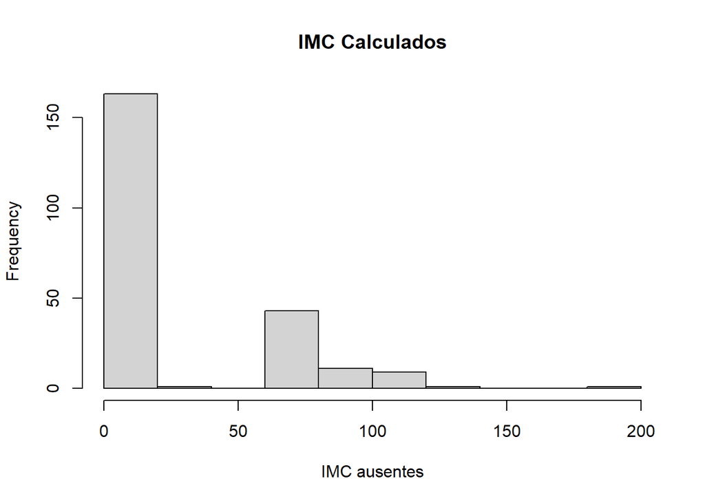

```r
hist(data2$IMC[i_IMC], main = "IMC Calculados", xlab = "IMC ausentes")
```

El cálculo de estos IMC revela que los datos de altura/peso o no son correctos, o tenemos mujeres en categoría de riesgo bien por delgadez extrema (IMC<15) u obesidad mórbida (IMC>40). Estos datos los vamos a filtrar posteriormente en el tratamiento de outliers.

Imputación missing values N_CIGARRILLOS

Imputamos los valores ausentes del número de cigarrillos por la mediana.

```r
sum(is.na(data2$N_CIGARRILLOS))
```

```
## [1] 7798
```

```r
i_cig <- is.na(data2$N_CIGARRILLOS)
data2$N_CIGARRILLOS[i_cig] <- median(data2$N_CIGARRILLOS[!i_cig])

sum(is.na(data2$N_CIGARRILLOS))
```

```
## [1] 0
```

```r
median(data2$N_CIGARRILLOS[!i_cig])
```

```
## [1] 0
```

Imputación missing values GANANCIA_PESO_MADRE

```r
sum(is.na(data2$GANANCIA_PESO_MADRE))
```

```
## [1] 23524
```

```r
i_gpes <- is.na(data2$GANANCIA_PESO_MADRE)
data2$GANANCIA_PESO_MADRE[i_gpes] <- median(data2$GANANCIA_PESO_MADRE[!i_gpes])

sum(is.na(data2$GANANCIA_PESO_MADRE))
```

```
## [1] 0
```

```r
median(data2$GANANCIA_PESO_MADRE)
```

```
## [1] 30
```

Imputación missing values PESO_NACER_GM

```r
sum(is.na(data2$PESO_NACER_GM))
```

```
## [1] 1258
```

```r
i_gpesn <- is.na(data2$PESO_NACER_GM)
data2$PESO_NACER_GM[i_gpesn] <- median(data2$PESO_NACER_GM[!i_gpesn])

sum(is.na(data2$PESO_NACER_GM))
```

```
## [1] 0
```

```r
median(data2$PESO_NACER_GM)
```

```
## [1] 3320
```

```r
summary(data2[,numvars])
```

```
##    EDAD_MADRE    PESO_MADRE_LB    ALTURA_MADRE        IMC
##  Min.   :12.00   Min.   : 75.0   Min.   :30.00   Min.   : 10.46
##  1st Qu.:24.00   1st Qu.:127.0   1st Qu.:62.00   1st Qu.: 21.80
##  Median :28.00   Median :145.0   Median :64.00   Median : 24.90
##  Mean   :28.12   Mean   :154.3   Mean   :64.25   Mean   : 26.26
##  3rd Qu.:32.00   3rd Qu.:174.0   3rd Qu.:66.00   3rd Qu.: 29.30
##  Max.   :50.00   Max.   :375.0   Max.   :78.00   Max.   :195.28
##  N_CIGARRILLOS    GANANCIA_PESO_MADRE PESO_NACER_GM
##  Min.   : 0.000   Min.   : 0.00       Min.   : 227
##  1st Qu.: 0.000   1st Qu.:20.00       1st Qu.:3005
##  Median : 0.000   Median :30.00       Median :3320
##  Mean   : 1.186   Mean   :30.07       Mean   :3293
##  3rd Qu.: 0.000   3rd Qu.:39.00       3rd Qu.:3635
##  Max.   :98.000   Max.   :98.00       Max.   :8165
```

### Identificación y tratamiento de Outliers

Los valores extremos pueden alterar las propiedades de las herramientas analítico estadísticas dando como resultado conclusiones erróneas en nuestros análisis. Vamos a tratar los valores atípicos de cada una da las variables.

### Identificación para las variables de la madre.

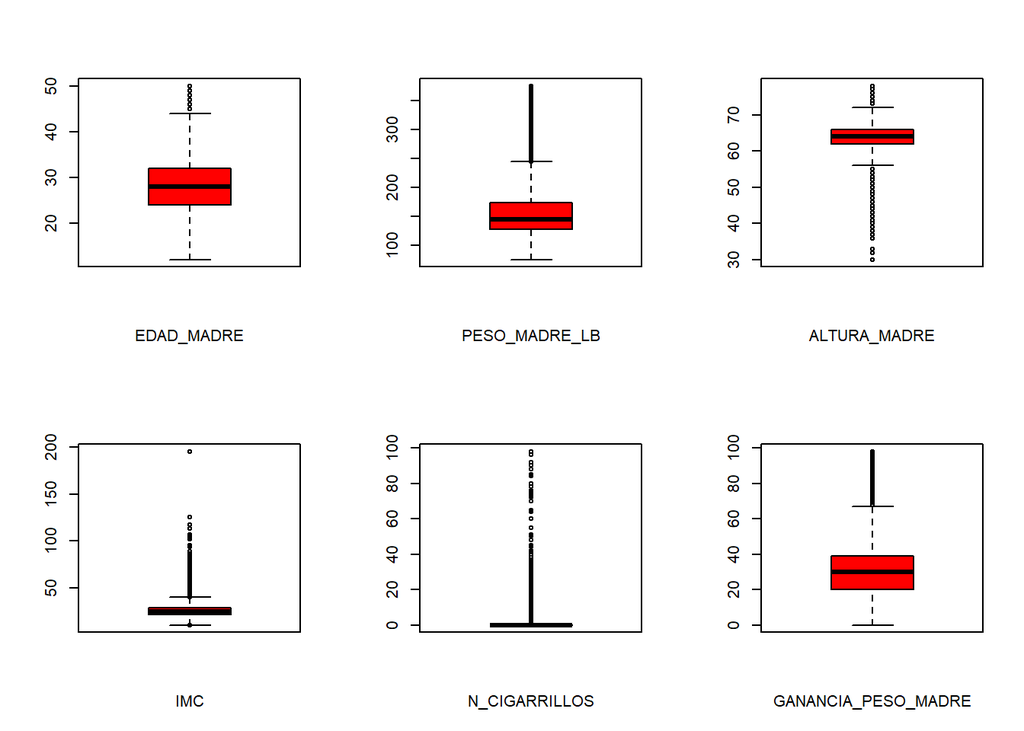

```r
conf2x3 = matrix(c(1:6), nrow=2, byrow=TRUE)
layout(conf2x3)

boxplot(data2$EDAD_MADRE, xlab = "EDAD_MADRE",col="red")
boxplot(data2$PESO_MADRE_LB, xlab = "PESO_MADRE_LB",col="red")
boxplot(data2$ALTURA_MADRE, xlab = "ALTURA_MADRE",col="red")
boxplot(data2$IMC, xlab = "IMC",col="red")
boxplot(data2$N_CIGARRILLOS, xlab = "N_CIGARRILLOS",col="red")
boxplot(data2$GANANCIA_PESO_MADRE, xlab = "GANANCIA_PESO_MADRE",col="red")
```

Porcentaje de outliers en las variables

```r
n_data2 <- nrow(data2)

sprintf("%% Outliers edad de la madre %0.2f%%", length(boxplot.stats(data2$EDAD_MADRE)$out)/n_data2*100)
```

```
## [1] "% Outliers edad de la madre 0.12%"
```

```r
sprintf("%% Outliers IMC de la madre %0.2f%%", length(boxplot.stats(data2$IMC)$out)/n_data2*100)
```

```
## [1] "% Outliers IMC de la madre 3.25%"
```

```r
sprintf("%% Outliers peso de la madre %0.2f%%", length(boxplot.stats(data2$PESO_MADRE_LB)$out)/n_data2*100)
```

```
## [1] "% Outliers peso de la madre 3.19%"
```

```r
sprintf("%% Outliers altura de la madre %0.2f%%", length(boxplot.stats(data2$ALTURA_MADRE)$out)/n_data2*100)
```

```
## [1] "% Outliers altura de la madre 0.46%"
```

```r
sprintf("%% Outliers cigarrillos fumados %0.2f%%", length(boxplot.stats(data2$N_CIGARRILLOS)$out)/n_data2*100)
```

```
## [1] "% Outliers cigarrillos fumados 8.98%"
```

```r
sprintf("%% Outliers ganancia de peso  de la madre %0.2f%%", length(boxplot.stats(data2$GANANCIA_PESO_MADRE)$out)
        /n_data2*100)
```

```
## [1] "% Outliers ganancia de peso  de la madre 1.44%"
```

### Discretización de la variable N_CIGARRILLOS

La variable N_CIGARRILLOS presenta un porcentaje importante de outliers y además el rango de la variable es demasiado elevado por lo que se va a proceder a discretizar la variable y así mantener sus propiedades.

```r
data2$N_CIGARRILLOS <- cut(data2$N_CIGARRILLOS, c(-Inf,0,10,20,40,Inf),
                           labels = c("No fumadora", "menos de 10", "entre 10 y 20", "entre 20 y 40", "40 o más"),
                           ordered = TRUE)

summary(data2$N_CIGARRILLOS)
```

```
##   No fumadora   menos de 10 entre 10 y 20 entre 20 y 40      40 o más
##       2019650        119115         67810         10223          2060
```

### Tratamiento Outliers EDAD_MADRE

```r
sprintf("%% Outliers edad de la madre %0.2f%%", length(boxplot.stats(data2$EDAD_MADRE)$out)/n_data2*100)
```

```
## [1] "% Outliers edad de la madre 0.12%"
```

```r
unique(boxplot.stats(data2$EDAD_MADRE)$out)
```

```
## [1] 47 45 50 46 48 49
```

Los valores extremos para la variable EDAD_MADRE suponen el 0.12% de la muestra, observamos que estas edades son perfectamente factibles en nuestros días, y no provienen de ningún error en los datos por lo que no será necesario realizar ningún tratamiento.

### Tratamiento Outliers IMC

```r
sprintf("%% Outliers IMC de la madre %0.2f%%", length(boxplot.stats(data2$IMC)$out)/n_data2*100)
```

```
## [1] "% Outliers IMC de la madre 3.25%"
```

```r
head(unique(boxplot.stats(data2$IMC)$out),50)
```

```
##  [1] 51.7 41.2 42.9 41.8 46.1 43.3 45.7 46.0 40.7 46.3 42.7 41.4 53.0 47.8 45.3
## [16] 40.8 44.5 43.0 48.4 40.6 42.3 41.6 57.7 46.8 41.0 41.3 41.1 52.3 44.1 43.9
## [31] 45.6 46.6 43.5 47.3 54.1 47.0 43.4 45.1 44.6 42.8 49.6 41.5 47.4 44.7 48.7
## [46] 47.1 50.7 41.7 42.2 57.2
```

```r
length(unique(boxplot.stats(data2$IMC)$out))
```

```
## [1] 328
```

```r
sum(unique(boxplot.stats(data2$IMC)$out)<15)
```

```
## [1] 1
```

```r
sum(unique(boxplot.stats(data2$IMC)$out)>40)
```

```
## [1] 327
```

En la variable IMC encontramos datos de madres que presentan obesidad mórbida o delgadez extrema y valores que están claramente mal imputados.

```r
i_imc <- which((data2$IMC < 16) | (data2$IMC > 40))
length(i_imc)
```

```
## [1] 85800
```

```r
data2$IMC[i_imc] = ((data2$PESO_MADRE_LB[i_imc]*703)/(data2$ALTURA_MADRE[i_imc])^2)
```

```r
length(unique(boxplot.stats(data2$IMC)$out))
```

```
## [1] 2097
```

Como podemos ver el error no proviene de un mal calculo del IMC sino que una de las dos variables Altura o Peso o las dos están mal imputadas dando valores en IMC sin sentido.

```r
head(unique(boxplot.stats(data2$IMC)$out),50)
```

```
##  [1] 51.74746 41.19141 42.92876 41.75302 46.06596 43.25098 45.72060 46.04698
##  [9] 40.67651 46.25657 42.73608 41.40046 53.03590 47.75408 45.34265 40.84814
## [17] 44.54270 42.96111 48.41598 41.19660 40.61946 42.28336 41.59763 57.74200
## [25] 42.90771 46.80211 40.73822 40.99731 41.34426 40.71731 41.14854 52.25120
## [33] 44.10913 43.93750 45.60986 46.63502 43.53620 47.25058 41.04888 41.62383
## [41] 40.59929 43.26154 41.76402 54.09194 41.31497 47.02686 43.37959 47.25491
## [49] 45.13892 44.61898
```

```r
length(unique(boxplot.stats(data2$IMC)$out))
```

```
## [1] 2097
```

```r
sum(unique(boxplot.stats(data2$IMC)$out)<15)
```

```
## [1] 1
```

```r
sum(unique(boxplot.stats(data2$IMC)$out)>40)
```

```
## [1] 2096
```

El resto de outliers corresponden con madres con obesidad mórbida o delgadez extrema, y por tanto factor de riesgo. Excluimos estos registros del análisis final.

```r
i_imc <- which((data2$IMC >= 16) & (data2$IMC <= 40))
data2 <- data2[i_imc,]
n_data2 <- nrow(data2)
```

### Tratamiento Outliers PESO_MADRE

```r
sprintf("%% Outliers peso de la madre %0.2f%%", length(boxplot.stats(data2$PESO_MADRE_LB)$out)/n_data2*100)
```

```
## [1] "% Outliers peso de la madre 1.57%"
```

```r
head(sort(unique(boxplot.stats(data2$PESO_MADRE_LB)$out)))
```

```
## [1] 235 236 237 238 239 240
```

```r
tail(sort(unique(boxplot.stats(data2$PESO_MADRE_LB)$out)))
```

```
## [1] 316 317 318 320 324 340
```

Los valores extremos para PESO_MADRE son factibles y no parece que procedan de errores de imputación de datos, sin embargo, nuestro estudio se basa en la suposición de que la madre cumple con unas condiciones estándar, entre las que se encuentran sin factores de riesgos por obesidad.

### Tratamiento Outliers ALTURA_MADRE

```r
sprintf("%% Outliers altura de la madre %0.2f%%", length(boxplot.stats(data2$ALTURA_MADRE)$out)/n_data2*100)
```

```
## [1] "% Outliers altura de la madre 0.42%"
```

```r
head(sort(unique(boxplot.stats(data2$ALTURA_MADRE)$out)))
```

```
## [1] 40 45 46 47 48 49
```

```r
tail(sort(unique(boxplot.stats(data2$ALTURA_MADRE)$out)))
```

```
## [1] 73 74 75 76 77 78
```

Como podemos observar los valores extremos provienen de mujeres con una estatura muy baja o muy alta, no apreciamos la presencia de errores de imputación en los datos, sin embargo, nos queremos centrar en madres con condiciones estándar por lo que prescindimos de los valores atípicos.

```r
quantile25 <- quantile(data2$ALTURA_MADRE,0.25)
quantile75 <- quantile(data2$ALTURA_MADRE,0.75)
l_inf <- quantile25-1.5*IQR(data2$ALTURA_MADRE)
l_sup <- quantile75+1.5*IQR(data2$ALTURA_MADRE)

data2 <- data2[data2$ALTURA_MADRE > l_inf & data2$ALTURA_MADRE < l_sup, ]
n_data2 <- nrow(data2)
```

### Tratamiento Outliers GANANCIA_PESO_MADRE

```r
sprintf("%% Outliers ganancia de peso  de la madre %0.2f%%", length(boxplot.stats(data2$GANANCIA_PESO_MADRE)$out)
        /n_data2*100)
```

```
## [1] "% Outliers ganancia de peso  de la madre 1.57%"
```

```r
head(sort(unique(boxplot.stats(data2$GANANCIA_PESO_MADRE)$out)),10)
```

```
##  [1] 67 68 69 70 71 72 73 74 75 76
```

```r
tail(sort(unique(boxplot.stats(data2$GANANCIA_PESO_MADRE)$out)),10)
```

```
##  [1] 89 90 91 92 93 94 95 96 97 98
```

La ganancia de peso durante el embarazo es factible, sin embargo, vamos a prescindir de los valores extremos ya que no suponen un número elevado de la muestra y mejoramos las propiedades de la muestra.

```r
quantile25 <- quantile(data2$GANANCIA_PESO_MADRE,0.25)
quantile75 <- quantile(data2$GANANCIA_PESO_MADRE,0.75)
l_inf <- quantile25-1.5*IQR(data2$GANANCIA_PESO_MADRE)
l_sup <- quantile75+1.5*IQR(data2$GANANCIA_PESO_MADRE)

data2 <- data2[data2$GANANCIA_PESO_MADRE > l_inf & data2$GANANCIA_PESO_MADRE < l_sup, ]
n_data2 <- nrow(data2)
```

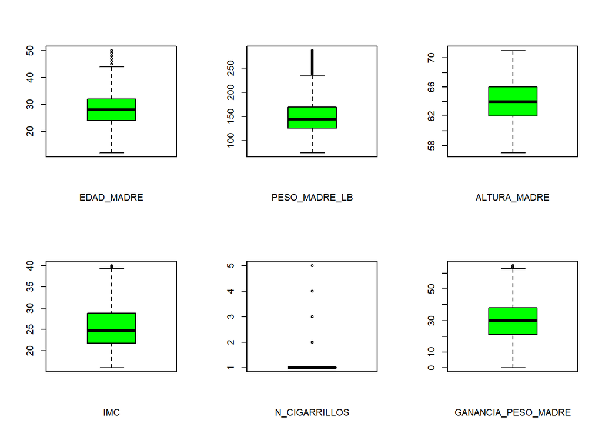

```r
conf2x3 = matrix(c(1:6), nrow=2, byrow=TRUE)
layout(conf2x3)

boxplot(data2$EDAD_MADRE, xlab = "EDAD_MADRE",col="green")
boxplot(data2$PESO_MADRE_LB, xlab = "PESO_MADRE_LB",col="green")
boxplot(data2$ALTURA_MADRE, xlab = "ALTURA_MADRE",col="green")
boxplot(data2$IMC, xlab = "IMC",col="green")
boxplot(data2$N_CIGARRILLOS, xlab = "N_CIGARRILLOS",col="green")
boxplot(data2$GANANCIA_PESO_MADRE, xlab = "GANANCIA_PESO_MADRE",col="green")
```

### Identificación para las variable PESO_NACER_GM del niño

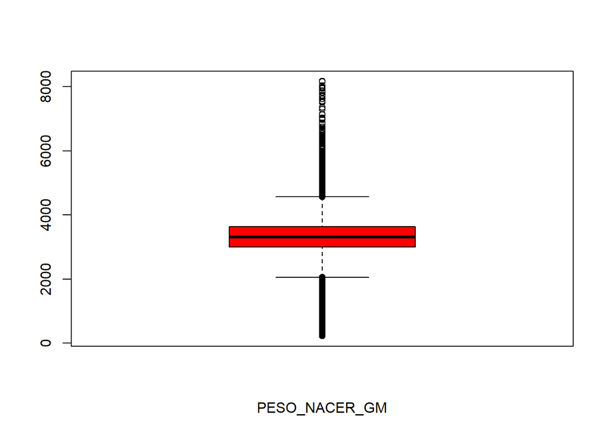

```r
boxplot(data2$PESO_NACER_GM, xlab = "PESO_NACER_GM",col="red")
```

```r
sprintf("%% Outliers del peso del bebe al nacer %0.2f%%",
        length(boxplot.stats(data2$PESO_NACER_GM)$out)/n_data2*100)
```

```
## [1] "% Outliers del peso del bebe al nacer 2.95%"
```

```r
head(sort(unique(boxplot.stats(data2$PESO_NACER_GM)$out)),10)
```

```
##  [1] 227 228 229 230 231 232 233 234 235 236
```

```r
tail(sort(unique(boxplot.stats(data2$PESO_NACER_GM)$out)),10)
```

```
##  [1] 7815 7853 7860 7875 7940 7975 8025 8160 8161 8165
```

Comprobamos que los valores son factibles y no se deben a ningún error de imputación. No necesita ningún tratamiento adicional.

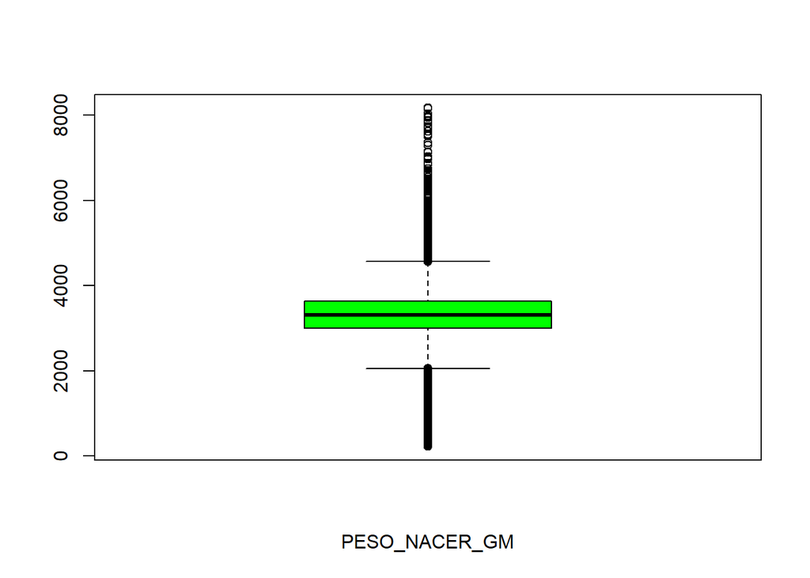

```r
boxplot(data2$PESO_NACER_GM, xlab = "PESO_NACER_GM",col="green")
```

Con este tratamiento consideramos que el dataset está preparado para los análisis que nos hemos planteado en este práctica. Vamos a salvar este dataset ya limpio en el fichero csv US2018_births_clean.csv

```r
# write.csv(data2, "US2018_births_clean.csv", sep = ";", col.names = TRUE, fileEncoding = "Latin1" )
```

Una vez limpios los datos vamos a proceder a realizar nuestros análisis y a resolver las cuestiones expresadas anteriormente.

## 4. Análisis de los datos

## 4.1 Selección de los grupos de datos que se quieren analizar/comparar (planificación de los análisis a aplicar).

```r
#RAZA
madres_rb <- data2$EDAD_MADRE[data2$RAZA_MADRE == "Caucasiana"]
madres_rn <- data2$EDAD_MADRE[data2$RAZA_MADRE == "Afroamericana"]

#ESTADO CIVIL
madres_s <- data2$EDAD_MADRE[data2$ESTADO_CIVIL == "Soltera"]
madres_c <- data2$EDAD_MADRE[data2$ESTADO_CIVIL == "Casada"]

#EDUCACION
madres_ei <- data2$EDAD_MADRE[data2$EDUC_MADRE == "8th grado o menos" |
                              data2$EDUC_MADRE == "De 9th a 12th grado sin diploma" |
                              data2$EDUC_MADRE == "Escuela secundaria o GED"]

madres_ei <- data2$EDAD_MADRE[!(data2$EDUC_MADRE == "8th grado o menos" |
                              data2$EDUC_MADRE == "De 9th a 12th grado sin diploma" |
                              data2$EDUC_MADRE == "Escuela secundaria o GED")]
```

En primer lugar, nuestras cuestiones se basan en la edad de la madre por tanto debemos contrastar si esta sigue una distribución normal y así realizar contrastes de hipótesis paramétricos o no paramétricos.

### Distribución de la variable EDAD_MADRE

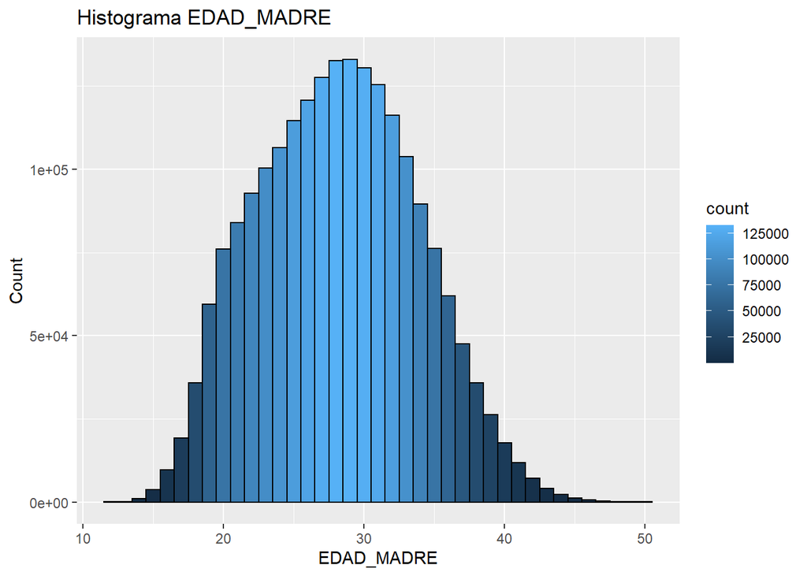

```r
pl <- ggplot(data2, aes(x=EDAD_MADRE))
pl2 = pl + geom_histogram(binwidth=1, aes(fill=..count..), col='black')
pl2 + xlab('EDAD_MADRE') + ylab('Count') + ggtitle('Histograma EDAD_MADRE')
```

Vamos a aplicar el test de normalidad de Anderson Darling.

```r
library(nortest)
ad.test(data2$EDAD_MADRE)
```

```
##
##  Anderson-Darling normality test
##
## data:  data2$EDAD_MADRE
## A = 5364.6, p-value < 2.2e-16
```

```r
#fligner.test(madres_rb ~ madres_rn)
```

## 4.3 Aplicación de pruebas estadísticas para comparar los grupos de datos. En función de los datos y el objetivo del estudio, aplicar pruebas de contraste de hipótesis, correlaciones, regresiones, etc. Aplicar al menos tres métodos de análisis diferentes.

### ¿Las madres de raza blanca y raza negra tienen su primer hijo a la misma edad?

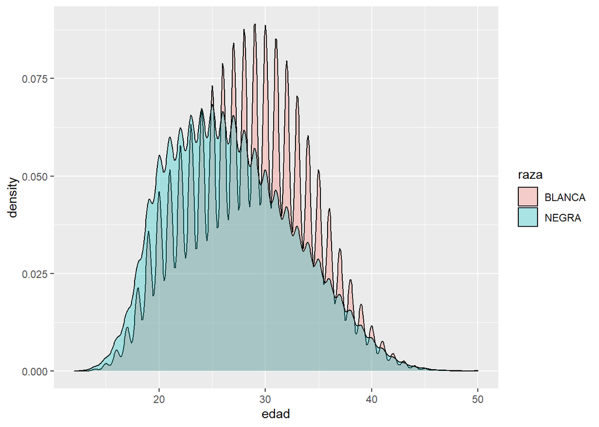

```r
tmp <- rbind(data.frame(raza = "BLANCA", edad = madres_rb),
       data.frame(raza = "NEGRA", edad = madres_rn))

ggplot(tmp, aes(x = edad, fill = raza)) + geom_density(alpha = 0.3)
```

### ¿Que factores sociológicos ,fisiológicos y culturales hacen que una madre tenga por primera vez un hijo?

### Análisis visual de las variables

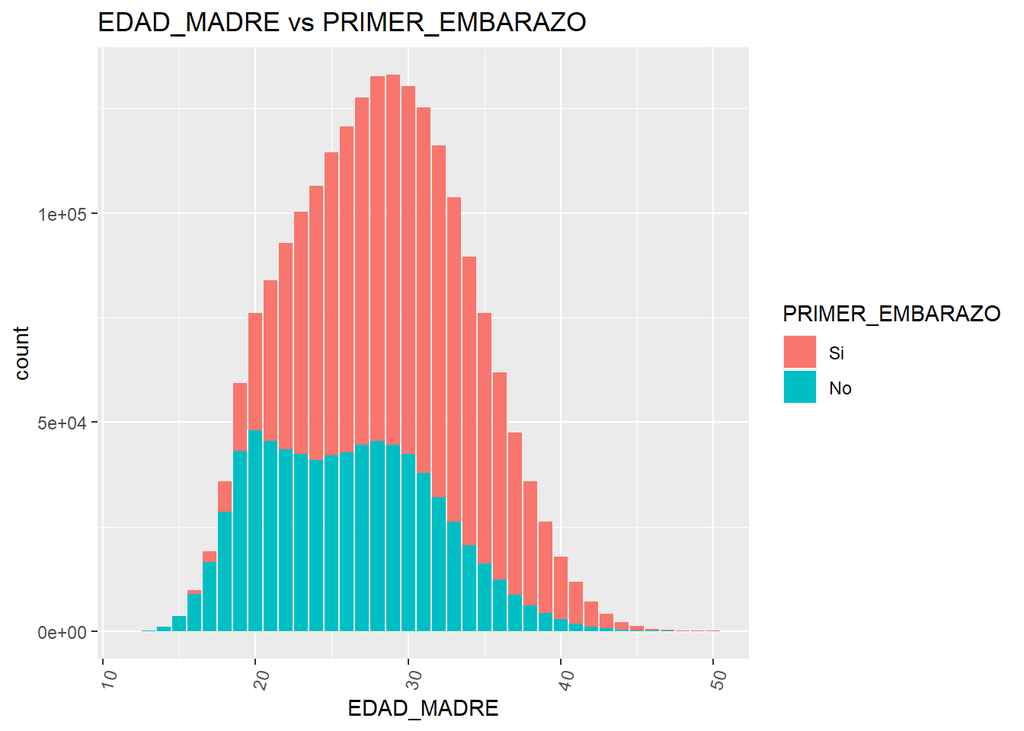

```r
ggplot(data=data2,aes(x=EDAD_MADRE,fill=PRIMER_EMBARAZO)) +
geom_bar(aes(x=EDAD_MADRE), stat = "count") +
theme(axis.text.x = element_text(angle = 75, vjust = 1, hjust=1)) +
   ggtitle('EDAD_MADRE vs PRIMER_EMBARAZO')
```

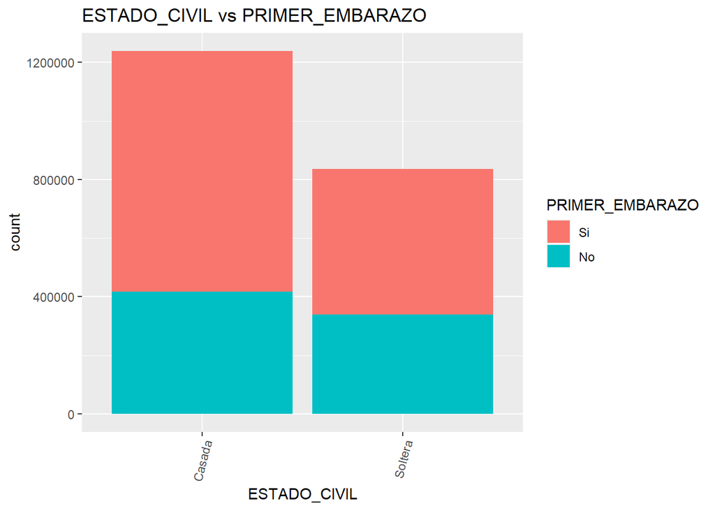

```r
ggplot(data=data2,aes(x=ESTADO_CIVIL,fill=PRIMER_EMBARAZO)) +
geom_bar(aes(x=ESTADO_CIVIL), stat = "count") +
theme(axis.text.x = element_text(angle = 75, vjust = 1, hjust=1)) +
   ggtitle('ESTADO_CIVIL vs PRIMER_EMBARAZO')
```

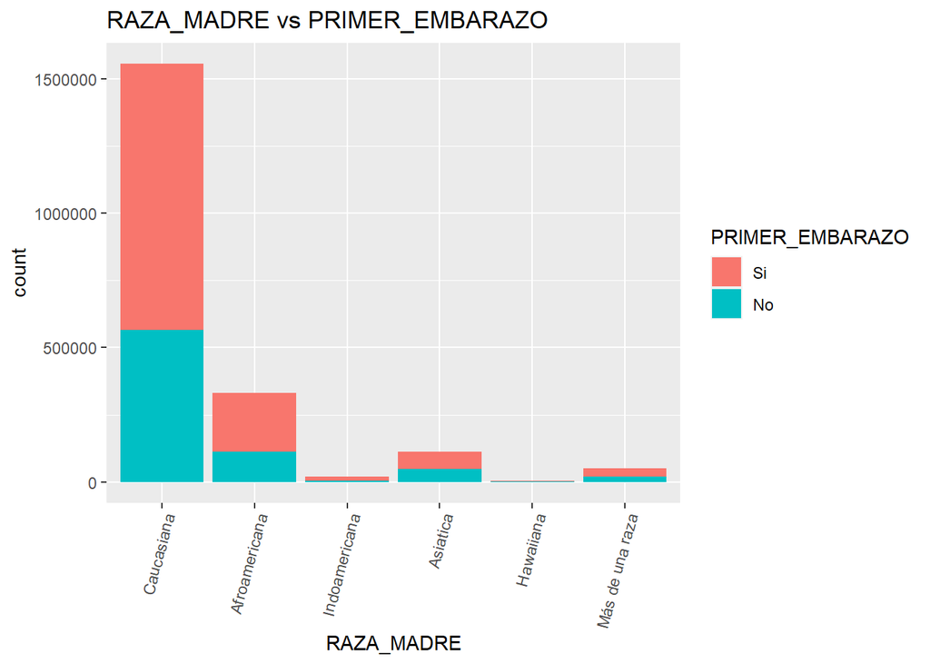

```r
ggplot(data=data2,aes(x=RAZA_MADRE,fill=PRIMER_EMBARAZO)) +
geom_bar(aes(x=RAZA_MADRE), stat = "count") +
theme(axis.text.x = element_text(angle = 75, vjust = 1, hjust=1)) +
   ggtitle('RAZA_MADRE vs PRIMER_EMBARAZO')
```

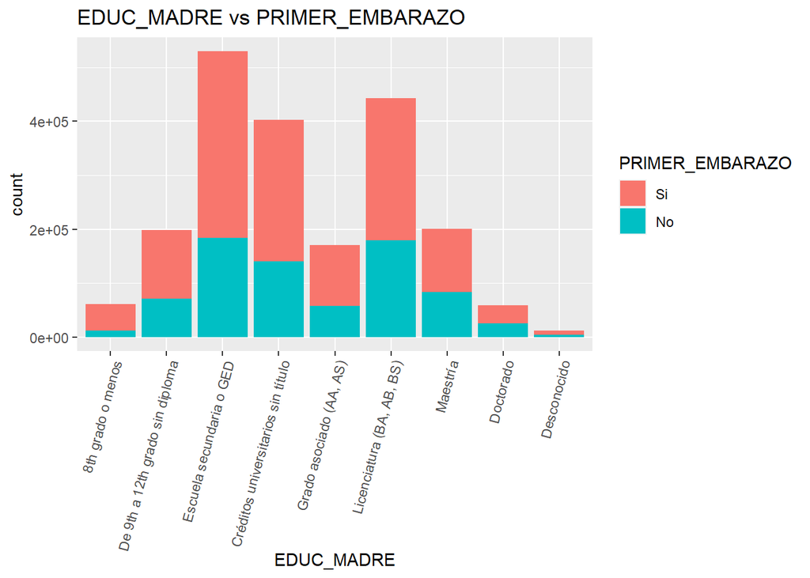

```r
ggplot(data=data2,aes(x=EDUC_MADRE,fill=PRIMER_EMBARAZO)) +
geom_bar(aes(x=EDUC_MADRE), stat = "count") +
theme(axis.text.x = element_text(angle = 75, vjust = 1, hjust=1)) +
   ggtitle('EDUC_MADRE vs PRIMER_EMBARAZO')
```

```r
model.logist1=glm(formula=data2$PRIMER_EMBARAZO~data2$EDAD_MADRE + data2$ESTADO_CIVIL + data2$RAZA_MADRE + data2$EDUC_MADRE ,family=binomial(link=logit))
summary(model.logist1)
```

```
##
## Call:
## glm(formula = data2$PRIMER_EMBARAZO ~ data2$EDAD_MADRE + data2$ESTADO_CIVIL +
##     data2$RAZA_MADRE + data2$EDUC_MADRE, family = binomial(link = logit))
##
## Deviance Residuals:
##     Min       1Q   Median       3Q      Max
## -2.1312  -0.9421  -0.5847   1.0783   3.4251
##
## Coefficients:
##                                                     Estimate Std. Error
## (Intercept)                                         3.337594   0.015340
## data2$EDAD_MADRE                                   -0.183721   0.000395
## data2$ESTADO_CIVILSoltera                           0.203528   0.003917
## data2$RAZA_MADREAfroamericana                      -0.198093   0.004543
## data2$RAZA_MADREIndoamericana                      -0.359478   0.016696
## data2$RAZA_MADREAsiatica                            0.467923   0.006878
## data2$RAZA_MADREHawaiiana                          -0.169800   0.030677
## data2$RAZA_MADREMás de una raza                    -0.156227   0.009920
## data2$EDUC_MADREDe 9th a 12th grado sin diploma     0.187203   0.012511
## data2$EDUC_MADREEscuela secundaria o GED            0.494186   0.011758
## data2$EDUC_MADRECréditos universitarios sin título  0.829217   0.011885
## data2$EDUC_MADREGrado asociado (AA, AS)             1.168590   0.012656
## data2$EDUC_MADRELicenciatura (BA, AB, BS)           1.837080   0.012017
## data2$EDUC_MADREMaestría                            2.157598   0.012654
## data2$EDUC_MADREDoctorado                           2.378624   0.014722
## data2$EDUC_MADREDesconocido                         0.955617   0.024660
##                                                     z value Pr(>|z|)
## (Intercept)                                         217.577  < 2e-16 ***
## data2$EDAD_MADRE                                   -465.118  < 2e-16 ***
## data2$ESTADO_CIVILSoltera                            51.958  < 2e-16 ***
## data2$RAZA_MADREAfroamericana                       -43.603  < 2e-16 ***
## data2$RAZA_MADREIndoamericana                       -21.530  < 2e-16 ***
## data2$RAZA_MADREAsiatica                             68.029  < 2e-16 ***
## data2$RAZA_MADREHawaiiana                            -5.535 3.11e-08 ***
## data2$RAZA_MADREMás de una raza                     -15.748  < 2e-16 ***
## data2$EDUC_MADREDe 9th a 12th grado sin diploma      14.963  < 2e-16 ***
## data2$EDUC_MADREEscuela secundaria o GED             42.030  < 2e-16 ***
## data2$EDUC_MADRECréditos universitarios sin título   69.770  < 2e-16 ***
## data2$EDUC_MADREGrado asociado (AA, AS)              92.332  < 2e-16 ***
## data2$EDUC_MADRELicenciatura (BA, AB, BS)           152.872  < 2e-16 ***
## data2$EDUC_MADREMaestría                            170.504  < 2e-16 ***
## data2$EDUC_MADREDoctorado                           161.564  < 2e-16 ***
## data2$EDUC_MADREDesconocido                          38.751  < 2e-16 ***
## ---
## Signif. codes:  0 '***' 0.001 '**' 0.01 '*' 0.05 '.' 0.1 ' ' 1
##
## (Dispersion parameter for binomial family taken to be 1)
##
##     Null deviance: 2722425  on 2075592  degrees of freedom
## Residual deviance: 2402750  on 2075577  degrees of freedom
## AIC: 2402782
##
## Number of Fisher Scoring iterations: 4
```

## CURVA ROC DEL MODELO

```r
library(pROC)
# Predicciones del modelo
prob=predict(model.logist1, data, type="response")
# Análisis ROC
r = roc(data2$PRIMER_EMBARAZO, prob, data=data,auc=T,ci=T)
```

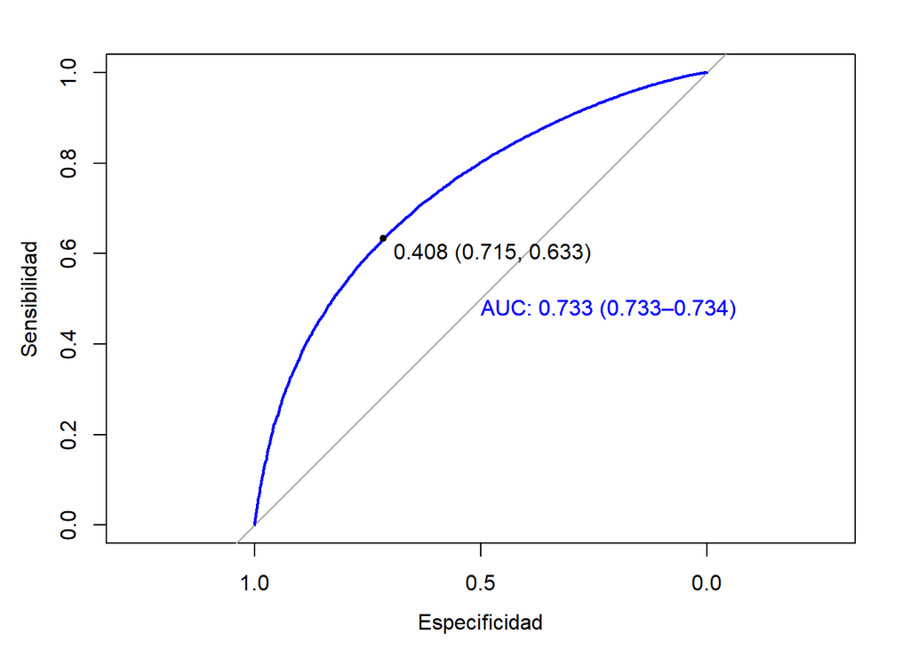

```r
plot.roc(r ,print.auc=T,print.thres = "best",
          col="blue",xlab="Especificidad",ylab="Sensibilidad")
```